# StockResearch

Gabriel Foix

2021-01-09

Buy Quality at the a good momentum and get rid of the fishy stocks on time. That's all.

### Define candidates

Download all info needed applying the following filters:

### Factor 1: Quality

1. Healthy debts: A company shoud generate cash in order to repay its debt. The **Free Cash Flow to Debt** ratio is a good indicator of how quick a company pays back its debt. The lower this ratio the better.

FCF2D = $\frac{Debt}{Free Cash Flow}$

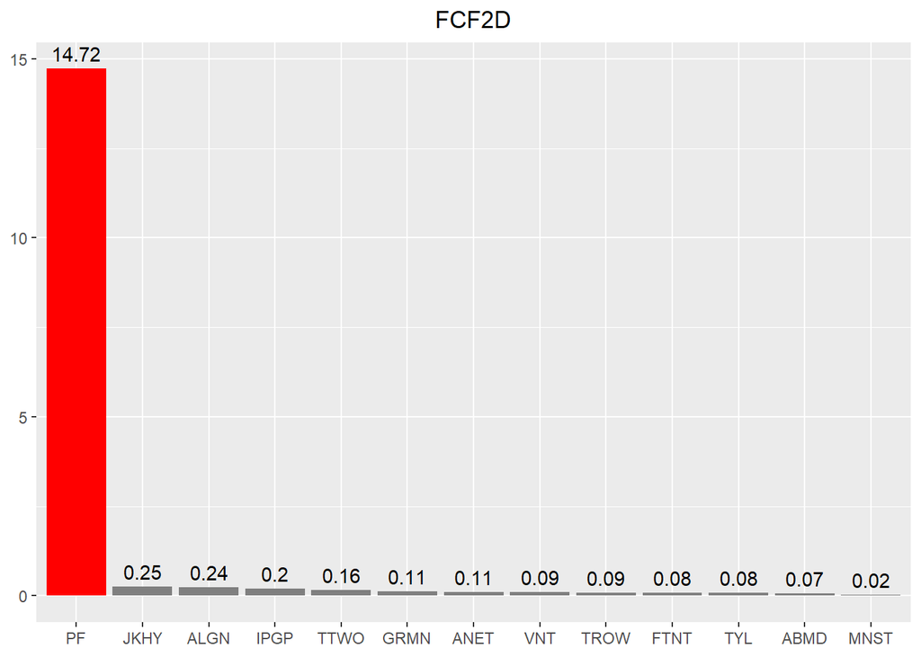

2. Profitability: ROA

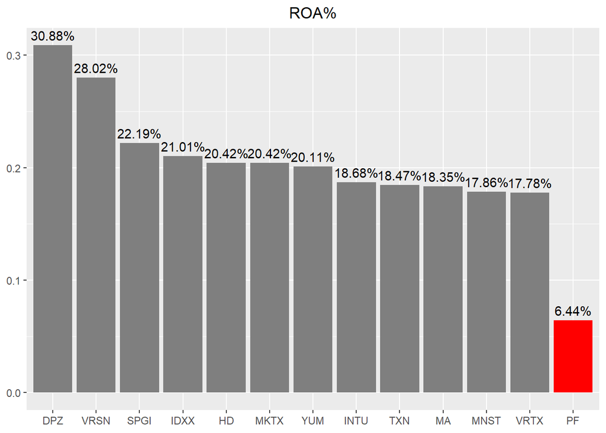

3. High Margin: We look for companies that generate free cash flow compare to its price. The **Free Cash Flow to Entreprise Value** ratio tells us how many years of cash flow would be needed to the return the 100% of the investment. Again, the lower, the better. Values bellow 1 would mean "free lunch".

FCF2EV = $\frac{EV}{Free Cash Flow}$

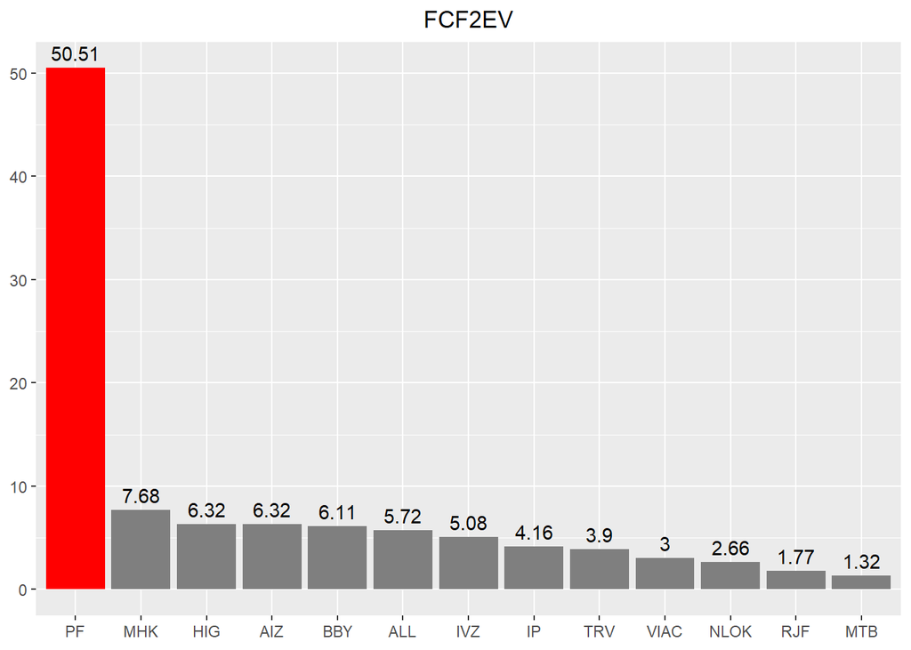

#### Download Historical Data

Download only stocks not filtered previously

### Value touch

Filter out stocks with PER > 40

Report Candidates

Filter Summary

| Filter | NStocks |
| --- | --- |
| Initial | 505 |
| ROA | 432 |
| FCF | 399 |
| Hist1Y | 395 |
| PER | 245 |

### Factor 2: Momentum

Don't hold onto a stock simply because it is high quality. So called quality stocks have cycles too. Stan Weinstein (page 177)

Generic Intermediate-Term Momentum Based on Gray-Vogel (page 80)

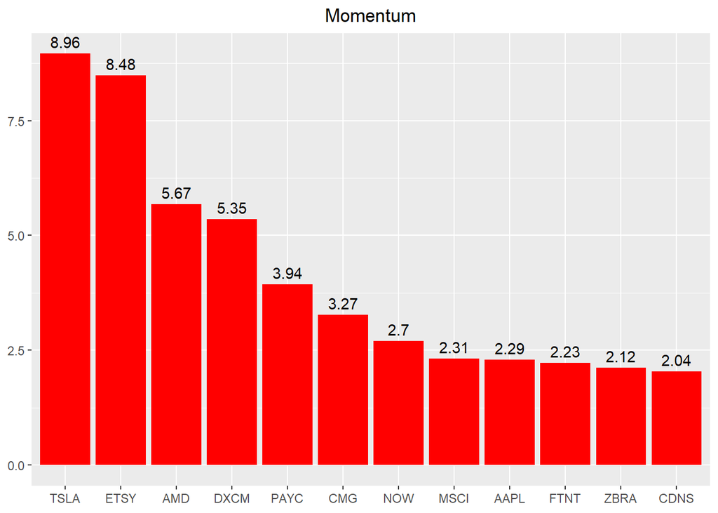

### Factor 3: Timing Signal

Sell Signal - Pr < 1% SMA 30 weeks and slope negative (< -0.2)  
Buy Signal - 109% * SMA30 < Pr > SMA 30 and slope positive (> 0.2)  
Hold Signal - Neither Buy nor Sell

#### Calc Market Cap

Using free float shares

### Summary

Summary

| Ticker | Signal | Quality | Momentum | Final_rank | PER | MCap |
| --- | --- | --- | --- | --- | --- | --- |
| TGT | HOLD | 391.0 | 371 | 427.0 | 25.679799 | 9.665690e+10 |
| COST | BUY | 409.0 | 341 | 426.0 | 37.981520 | 1.633900e+11 |
| PGR | BUY | 395.0 | 336 | 421.0 | 10.948905 | 5.512153e+10 |
| TER | HOLD | 353.0 | 376 | 418.5 | 33.806599 | 2.186791e+10 |
| SPGI | HOLD | 396.0 | 323 | 416.0 | 32.760349 | 7.851665e+10 |
| TSCO | BUY | 388.0 | 329 | 415.0 | 23.206403 | 1.730656e+10 |
| ACN | HOLD | 417.0 | 298 | 413.0 | 32.516002 | 1.672651e+11 |
| CDNS | HOLD | 331.0 | 384 | 413.0 | 35.309827 | 3.742540e+10 |
| FAST | BUY | 384.0 | 331 | 413.0 | 34.760274 | 2.902279e+10 |
| KLAC | HOLD | 344.5 | 370 | 411.0 | 34.441741 | 4.364589e+10 |
| ODFL | BUY | 375.0 | 337 | 409.0 | 38.968720 | 2.105631e+10 |
| GRMN | HOLD | 366.0 | 344 | 408.0 | 22.898443 | 1.716155e+10 |
| PWR | HOLD | 382.5 | 326 | 406.0 | 28.119912 | 1.042415e+10 |
| HCA | HOLD | 413.0 | 295 | 405.0 | 17.419616 | 4.546034e+10 |
| LOW | BUY | 408.0 | 277 | 402.0 | 23.348423 | 1.208174e+11 |
| CTAS | BUY | 314.5 | 354 | 400.0 | 39.276500 | 3.143633e+10 |
| PG | HOLD | 358.0 | 308 | 399.0 | 26.522070 | 3.437590e+11 |
| MCO | HOLD | 344.5 | 320 | 398.0 | 29.173346 | 5.240676e+10 |
| TROW | HOLD | 428.0 | 235 | 396.5 | 17.379373 | 3.432712e+10 |
| AMAT | HOLD | 364.5 | 296 | 394.5 | 24.377550 | 8.695882e+10 |
| CHD | HOLD | 338.5 | 322 | 394.5 | 27.628600 | 2.116547e+10 |
| BBY | HOLD | 424.0 | 236 | 393.0 | 16.392868 | 2.491185e+10 |
| MSFT | HOLD | 292.5 | 367 | 392.0 | 35.428294 | 1.636161e+12 |
| EXPD | BUY | 405.0 | 252 | 391.0 | 25.470731 | 1.587371e+10 |
| TXN | HOLD | 378.0 | 278 | 390.0 | 32.398259 | 1.568573e+11 |
| CLX | SELL | 394.0 | 255 | 388.0 | 21.989552 | 2.484694e+10 |
| SWKS | HOLD | 361.0 | 287 | 386.5 | 34.058332 | 2.704542e+10 |
| VRSN | HOLD | 317.0 | 325 | 383.0 | 29.203693 | 2.147667e+10 |
| LRCX | HOLD | 269.0 | 372 | 382.0 | 28.503324 | 7.197134e+10 |
| HD | HOLD | 421.0 | 219 | 381.0 | 23.275668 | 2.893027e+11 |

[output cut: 215 more lines]

Save output in template